# Note: A/B test

Weiquan Luo

2021-02-11

### Use of this document

This is a study note for AB test with using $pwr$ pakcage. I mainly use this as a cheatsheet for calculation.

(source: [Power and Sample Size Determination](https://sphweb.bumc.bu.edu/otlt/mph-modules/bs/bs704_power/bs704_power_print.html#:~:text=The%20formula%20for%20determining%20sample%20size%20to%20ensure%20that%20the,%3D%200.975%20and%20Z%3D1.960.))

# 1. Summary

Notation:

- $n$: sample size
- $Z$: Standard score or Z-score,
- $E$: Margin of error, where is $\mu_2 - \mu_1$ for continuous outcome, or $p_2-p_1$ for dichotomous outcome, or in general form $\frac{Z \sigma}{\sqrt{n}}$.
- $ES$: Effect size, which is $\frac{E}{\sigma}$, which is on the Z-scale.
- $\alpha$: significant level
- $1-\beta$: pwer of test
- $\mu$: mean of the sample for continuous outcome.
- $p$: porportion of success for dichotomous outcome

Sample Size to Estimate Confidence Interval, which only consider the level of confidence $1-\alpha$

| Type of Outcome | one sample | Two Independent Samples | match sample |
| --- | --- | --- | --- |
| Dichotomous (Bernoulli) | $n = p(1-p)(\frac{Z}{E})^2$ | $n_i = (p_1(1-p_1)+p_2(1-p_2))(\frac{Z}{E})^2$ | - |
| Continuous (Gaussian) | $n = (\frac{Z\sigma}{E})^2$ | $\begin{matrix} n_i = 2(\frac{Z\sigma}{E})^2 \\ \sigma = S_p = \sqrt{\frac{(n_1-1)s_1^2+(n_2-1)s_2^2}{n_1+n_2-2}} \end{matrix}$ | $n = (\frac{Z\sigma_d}{E})^2$ |

Sample Size to Conduct Test of Hypothesis, where $\alpha$ is level of significance, and $1- \beta$ is level of power

| Type of Outcome | one sample | Two Independent Samples | match sample |
| --- | --- | --- | --- |
| Dichotomous (Bernoulli) | $\begin{matrix} n = (\frac{Z_{1-\alpha/2}+Z_{1-\beta}}{ES})^2 \\ ES = \frac{p_1-p_0}{\sqrt{p_1(1-p_1)}} \end{matrix}$ | $\begin{matrix} n = 2(\frac{Z_{1-\alpha/2}+Z_{1-\beta}}{ES})^2 \\ ES = \frac{\|p_2-p_1\|}{\sqrt{p(1-p)}} \\ p = \frac{p_1 + p_2}{2} \end{matrix}$ | - |
| Continuous (Gaussian) | $\begin{matrix} n = (\frac{Z_{1-\alpha/2}+Z_{1-\beta}}{ES})^2 \\ ES = \frac{\|\mu_1-\mu_0\|}{\sigma} \end{matrix}$ | $\begin{matrix} n = 2(\frac{Z_{1-\alpha/2}+Z_{1-\beta}}{ES})^2 \\ ES = \frac{\|\mu_1-\mu_2\|}{\sigma} \\ \sigma = S_p = \sqrt{\frac{(n_1-1)s_1^2+(n_2-1)s_2^2}{n_1+n_2-2}} \end{matrix}$ | $\begin{matrix} n = (\frac{Z_{1-\alpha/2}+Z_{1-\beta}}{ES})^2 \\ ES = \frac{\mu_d}{\sigma_d} \end{matrix}$ |

# 2. R function

Function in $pwr$ R package to calculate the sample size

| Type of Outcome | one sample | Two Independent Samples | match sample |
| --- | --- | --- | --- |
| Dichotomous (Bernoulli) | `pwr::pwr.p.test()` | `pwr::pwr.2p.test()` | - |
| Continuous (Gaussian) | `pwr::pwr.t.test()` | `pwr::pwr.t.test()` | `pwr::pwr.t.test()` |

Function in $pwr$ R package to calculate significance of a test.

| Type of Outcome | one sample | Two Independent Samples | match sample |
| --- | --- | --- | --- |
| Dichotomous (Bernoulli) | `pwr::pwr.p.test()` | `pwr::pwr.2p.test()`, `pwr::pwr.2p2n.test()` (different sizes) | - |
| Continuous (Gaussian) | `pwr::pwr.t.test()` | `pwr::pwr.t.test()`, `pwr::pwr.t2n.test()` (different sizes) | `pwr::pwr.t.test()` |

Other function:

- `pwr::pwr.2p2n.test()`: Power calculation for two proportions (different sample sizes)
- `pwr::pwr.t2n.test()`: Power calculations for two samples (different sizes) t-tests of means
- `pwr::pwr.norm.test()`: Power calculations for the mean of a normal distribution (known variance)
- `pwr::pwr.r.test()`: Power calculations for correlation test
- `pwr::pwr.anova.test()`: Power calculations for balanced one-way analysis of variance tests
- `pwr::pwr.chisq.test()`: power calculations for chi-squared tests
- `pwr::pwr.f2.test()`: Power calculations for the general linear model

# 3. Type I Error and Type II Error

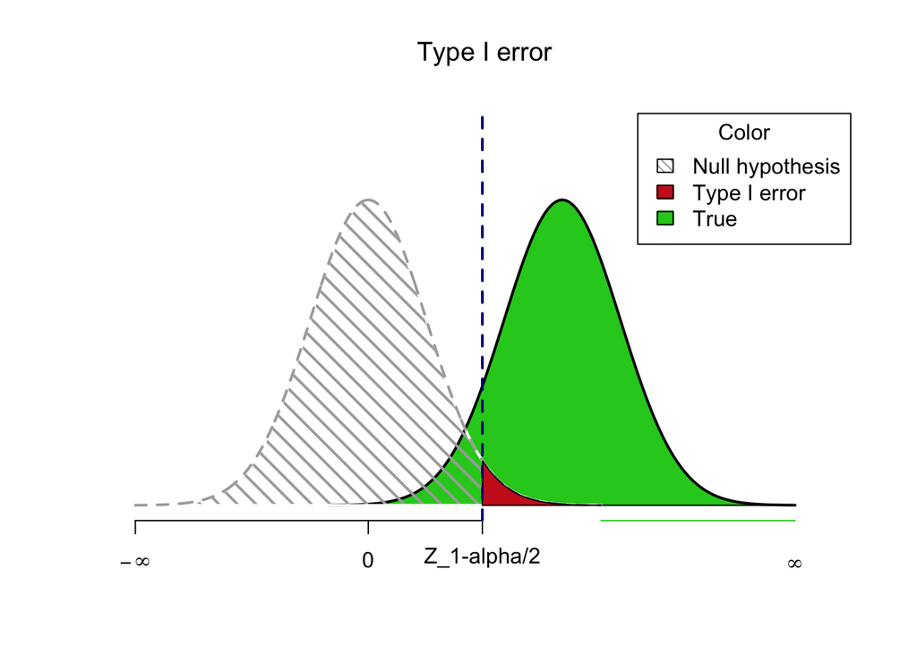

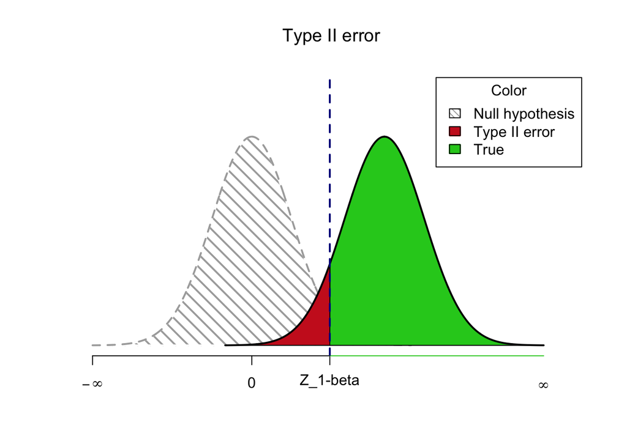